# Homework 12

Brittany Verrico

4/11/2018

Generate a fake data set to make figures for local adaptation hypotheses. The reaction norm will be continuous because I am utilizing the transfer distance approach.

```
Transfer distance = (Climate at collection site) - (Climate at planting site)
```

If populations are locally adapted, then fitness is highest when the transfer distance is 0. That is, the home and planting site climatic conditions (based on a particular variable) are the same/similar. Fitness should decrease as transfer distance increases.

I would also like to plot the range of transfer distances for collections of trees collected at two scales. Again, not going into the details.

Load in the required packages

```r
library(ggplot2)
library(patchwork)
library(cowplot)
```

Generate a fake, but realistic data set.

Low elevation

```r
lowSeq=seq(0,4,.01)
# create a normal distribution, with a mean of 0
lowdensities<-dnorm(lowSeq, mean=0,sd=0.6)
# but only keep those value greater than 0 because I will not have negative td in my experiment
lowdensities2=lowdensities[lowdensities>=0]
BroadScale=rep("Broad-scale", length(lowdensities2))
# put everything in a data frame
lowMat=data.frame(x=lowSeq, y=lowdensities2, scale=BroadScale)
```

No local adaptation at low elevation

```r
# create a fake y value
noLALow=rep(0.2,length(lowdensities2))
FineScale=rep("Fine-scale", length(lowdensities2))
noLAmat=data.frame(x=lowSeq, y=noLALow, scale=FineScale)

# create combined matrix for plotting
plot_matLow=rbind(lowMat, noLAmat)
```

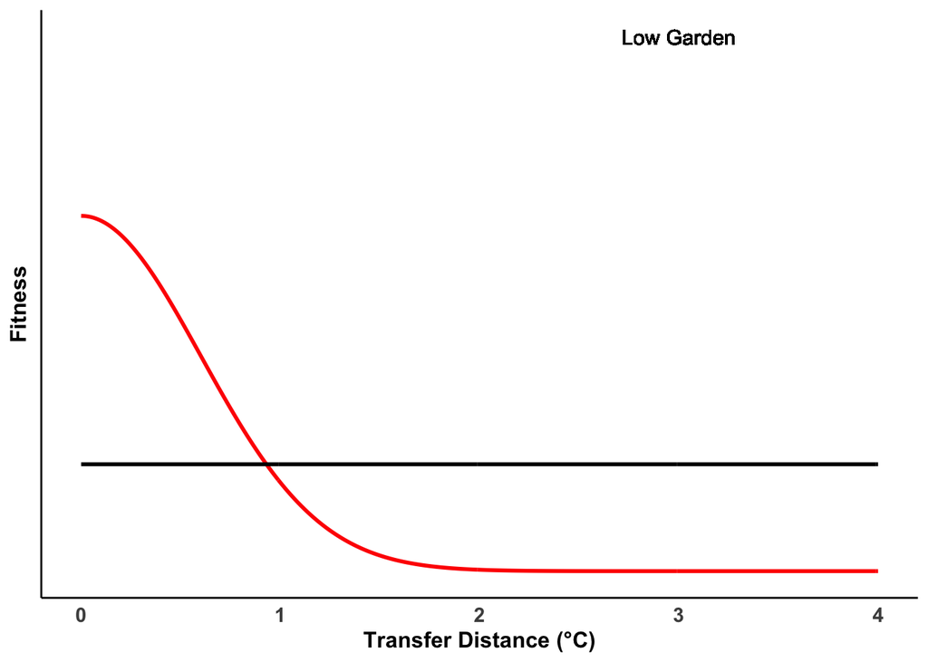

```r
# plot local adaptation of low elevation
Low=ggplot(data= plot_matLow, mapping = aes(x=x, y=y, group=factor(scale))) + geom_line(aes(color=scale), size=1) + theme_classic() +
  ylab("Fitness") +
  xlab("Transfer Distance (°C)")+
  theme(axis.text.y = element_blank(), axis.ticks = element_blank(), axis.title.x = element_text(size=12, face="bold"),
        axis.title.y = element_text(size=12, face="bold"),
        axis.text.x = element_text(face="bold",size=11), legend.position = "none") + scale_color_manual(values=c('red','black')) +
  geom_text(aes(3,1, label = "Low Garden"), size=4)
print(Low)
```

Mid elevation

```r
mid<-seq(-2,2,.01)
middensities<-dnorm(mid, mean=0,sd=0.3)
BroadScale=rep("Broad-scale", length(lowdensities2))
midMat=data.frame(x=mid, y=middensities, scale=BroadScale)
```

No local adaptation at mid elevation

```r
# create a fake y value
noLAmid=rep(0.2,length(lowdensities2))
FineScale=rep("Fine-scale", length(middensities))
noLAmatMid=data.frame(x=mid, y=noLAmid, scale=FineScale)

# create combined matrix for plotting
plot_matMid=rbind(midMat, noLAmatMid)
```

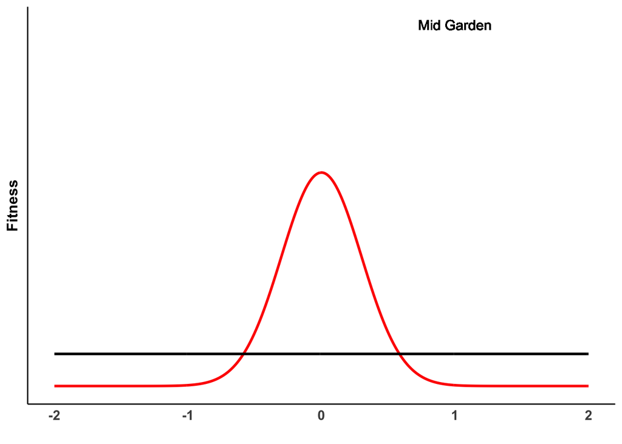

```r
# plot local adaptation of low elevation
Mid=ggplot(data= plot_matMid, mapping = aes(x=x, y=y, group=factor(scale))) + geom_line(aes(color=scale), size=1) + theme_classic() +
  ylab("Fitness") +
  xlab("")+
  theme(axis.text.y = element_blank(), axis.ticks = element_blank(), axis.title.x = element_text(size=12, face="bold"),
        axis.title.y = element_text(size=12, face="bold"),
        axis.text.x = element_text(face="bold",size=11), legend.position = "none") + scale_color_manual(values=c('red','black')) +
  geom_text(aes(1,2.25, label = "Mid Garden"), size=4)
print(Mid)
```

High elevation

```r
high<-seq(-4,0,.01)
highdensities<-dnorm(high, mean=0,sd=0.3)
highdensities2=highdensities[highdensities>=0]
BroadScale=rep("Broad-scale", length(highdensities2))
highMat=data.frame(x=high, y=highdensities2, scale=BroadScale)
```

No local adaptation at high elevation

```r
# create a fake y value
noLAhigh=rep(0.2,length(highdensities2))
FineScale=rep("Fine-scale", length(highdensities2))
noLAmatHigh=data.frame(x=high, y=noLAhigh, scale=FineScale)

# create combined matrix for plotting
plot_mat=rbind(highMat, noLAmatHigh)
```

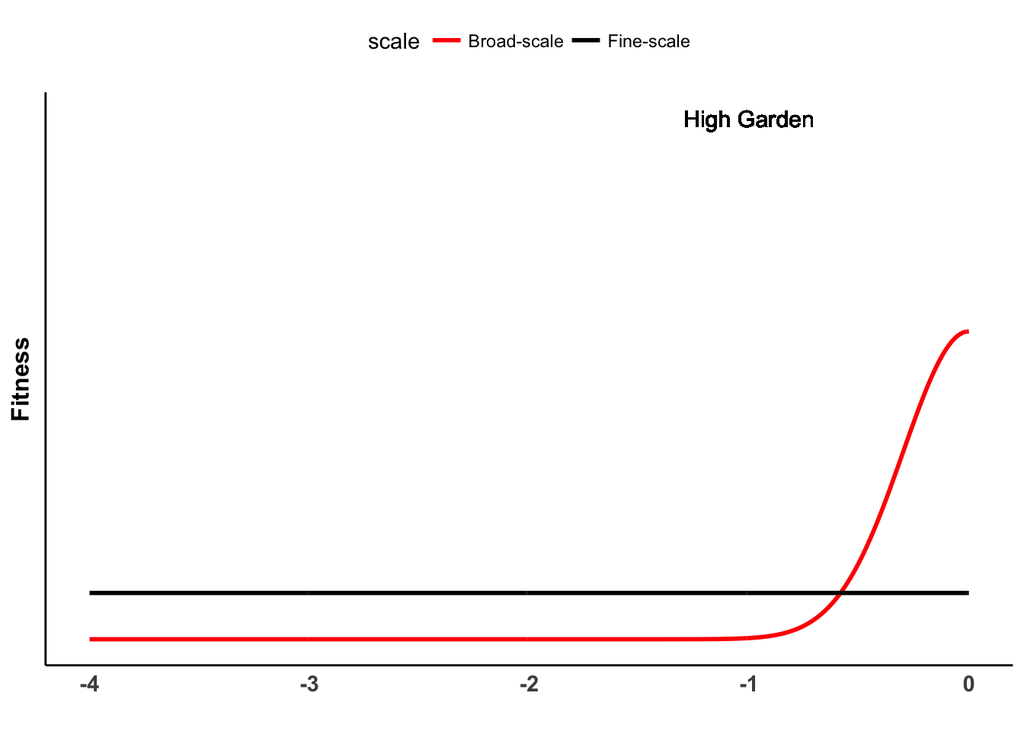

```r
# plot local adaptation of low elevation
High=ggplot(data= plot_mat, mapping = aes(x=x, y=y, group=factor(scale))) + geom_line(aes(color=scale), size=1) + theme_classic() +
  ylab("Fitness") +
  xlab("")+
  theme(axis.text.y = element_blank(), axis.ticks = element_blank(), axis.title.x = element_text(size=12, face="bold"),
        axis.title.y = element_text(size=12, face="bold"),
        axis.text.x = element_text(face="bold",size=11), legend.position = "top") + scale_color_manual(values=c('red','black')) +
  geom_text(aes(-1,2.25, label = "High Garden"), size=4)
print(High)
```

If patchwork does not work, then this can be an alternative.

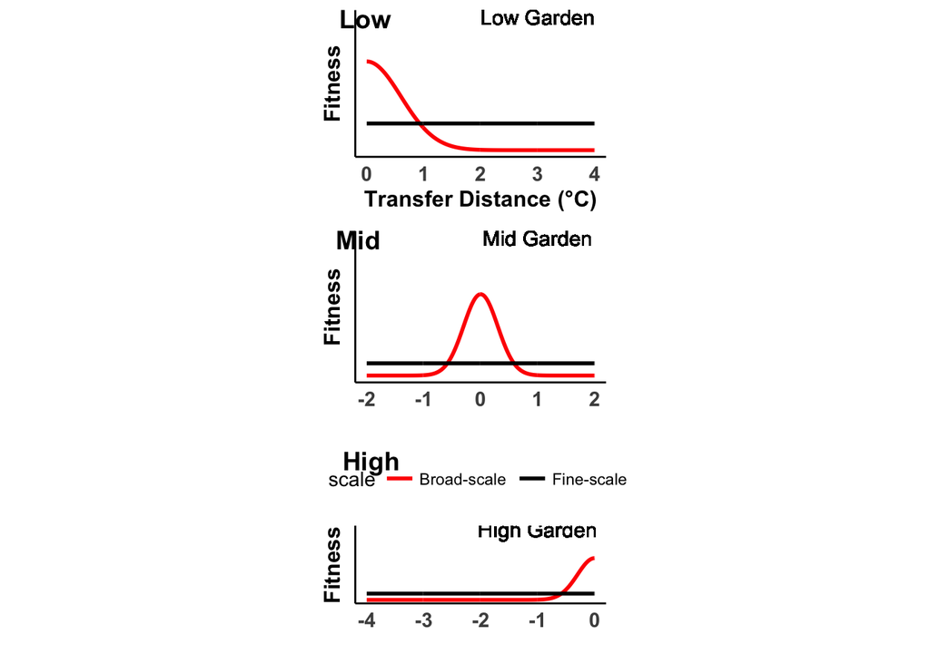

```r
plot_grid(Low, Mid, High, labels = c("Low", "Mid", "High"), align = "v", nrow=3) + theme(plot.margin = unit(c(0,6,0,6), "cm"))
```

```r
#ggsave(filename = "/Volumes/kellrlab/brittany/dissertation/Grants/Marvin/LocalAdaptationHo.pdf", plot=plotMe, device = "pdf")
```

Plot transfer distances between scales.

```r
td=read.csv("/Volumes/kellrlab/datashare/Spruce/MansfieldCG/CommonGardenPlans/TDplot.csv", header=TRUE)
head(td)
```

```
##   X              id         td garden scale tally
## 1 1 MMF_01_09022017 -0.4729948      5  Fine    33
## 2 2 MMF_01_09022017  0.8570103      3  Fine    33
## 3 3 MMF_01_09022017  2.6646933      1  Fine    33
## 4 4 MMF_02_09022017 -0.4776779      5  Fine    32
## 5 5 MMF_02_09022017  0.8523272      3  Fine    32
## 6 6 MMF_02_09022017  2.6600101      1  Fine    32
```

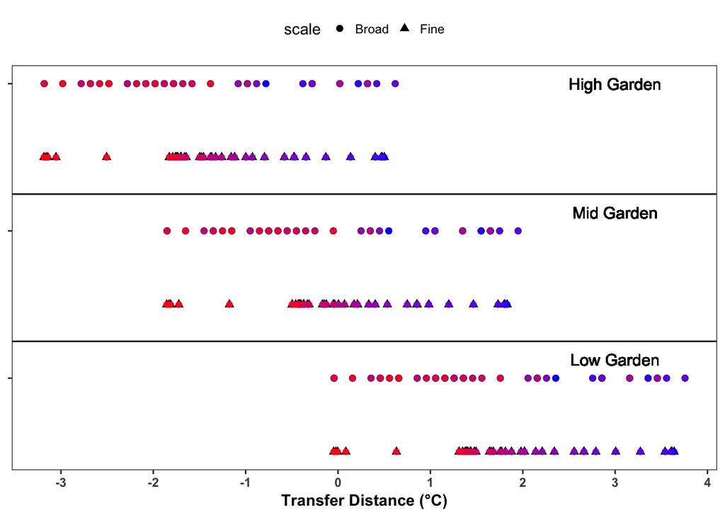

```r
tdplot=ggplot(data=td, aes(x=td, y=garden)) + geom_point(aes(shape =scale), size = 2) + geom_point(aes(color =tally)) +
  scale_x_continuous(breaks=seq(from=-4, to=4, by=1))+ theme_bw() +
  theme(panel.grid = element_blank(), axis.text.y = element_blank(), axis.title.y = element_blank(), axis.text.x = element_text(face="bold"), axis.title.x = element_text(face="bold"), legend.position = "top") + labs(x="Transfer Distance (°C)")+ geom_hline(yintercept = 2.5) +
   geom_hline(yintercept = 4.5) +
geom_text(aes(3,2.25, label = "Low Garden"), size=4) +
geom_text(aes(3,4.25, label = "Mid Garden"), size=4) +
  geom_text(aes(3,6, label = "High Garden"), size=4) +
  scale_colour_gradient(low = "red",high = "blue") +
  guides(colour=FALSE)
print(tdplot)
```

Try plotting everything together. This could look better, but I think it looks okay for now.

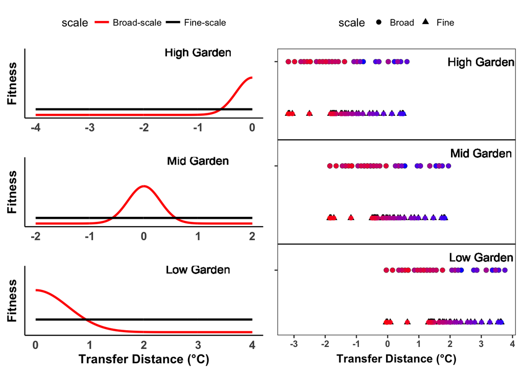

```r
High + Mid + Low + plot_layout(ncol=1) | tdplot
```